# A spoonful of ggplot2 3.3.0

Embracing an exciting update overflowed with new features

Qiushi Yan https://qiushi.rbind.io (Communication University of China)http://www.cuc.edu.cn/  
03-06-2020

# Embracing `ggplot2` 3.3.0

```r
library(tidyverse)
packageVersion("ggplot2")
```

```
#> [1] '3.3.0.9000'
```

## New guide function `guide_axis()`

As is the way with many ggplot2 users, guide functions are most represented by `guide_legend()` and `guide_colorbar`, which are related to some non-positional aesthetics. However, axis is essentialy a guide in itself, mapping positions back to the value of a continuous / discrete variable. While, at a high level, axes and legends are equivalent (they are both guides used for scales). All of this is contained in the new `guide_axis()` function that works equivalently to e.g. `guide_legend()`.

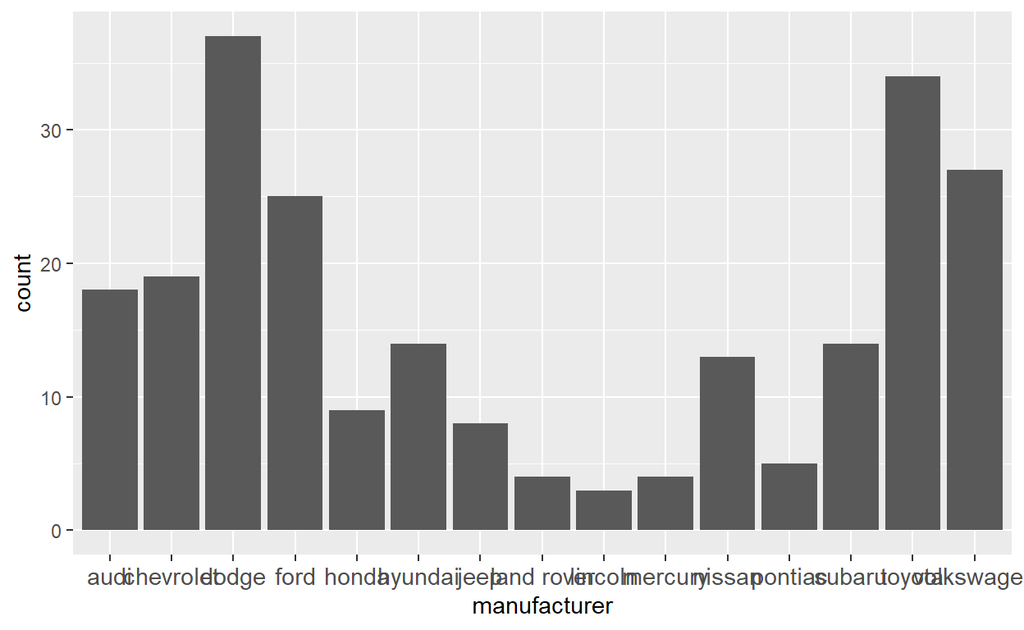

```r
# plot with overlapping text
p <- ggplot(mpg) +
  geom_bar(aes(x = manufacturer)) +
  theme(axis.text.x = element_text(size = 11))

# Overlapping labels
p
```

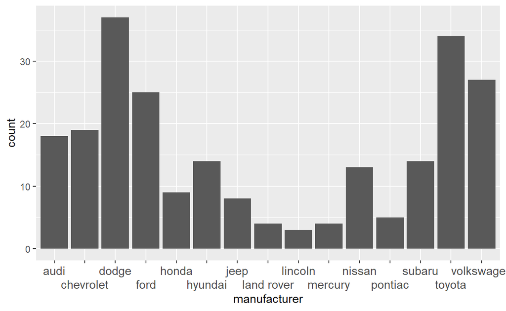

```r
# axis guides can be customized in the scale_* functions or
# using guides()
p + scale_x_discrete(guide = guide_axis(n.dodge = 2))
```

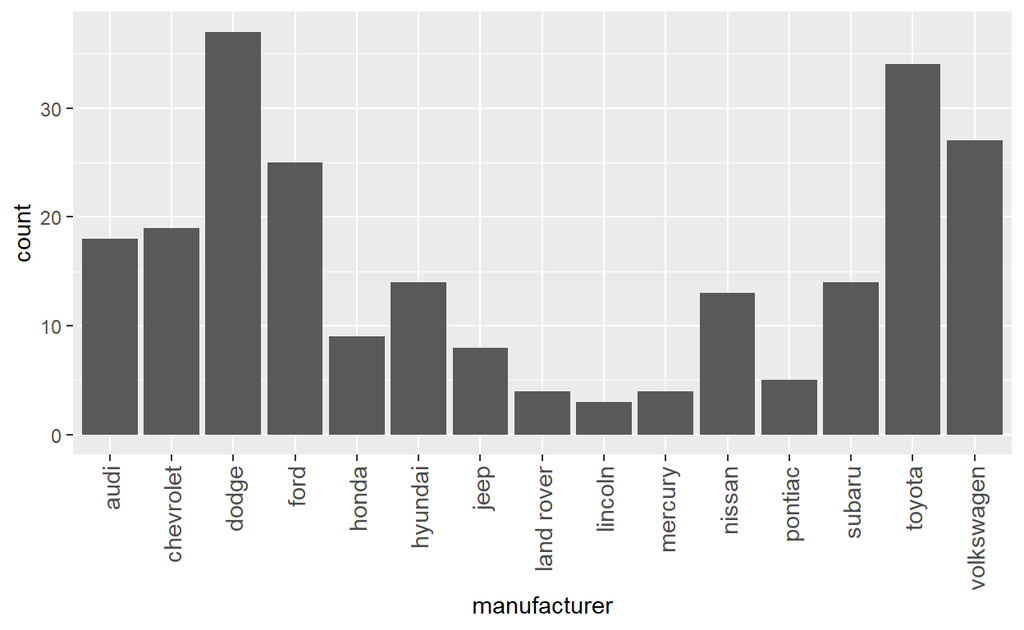

```r
p + guides(x = guide_axis(angle = 90))
```

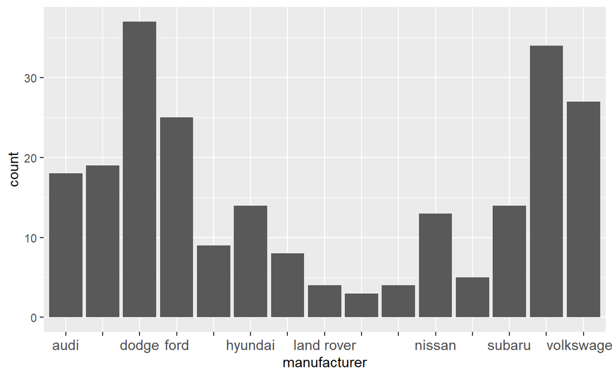

```r
# Or to remove overlapping labels
p +
  scale_x_discrete(guide = guide_axis(check.overlap = TRUE))
```

Other arguments in `guide_axis()` include `title`, `order`( Used to determine the order of the guides (left-to-right, top-to-bottom), if more than one guide must be drawn at the same location.) and `position`(Where this guide should be drawn: one of top, bottom, left, or right)

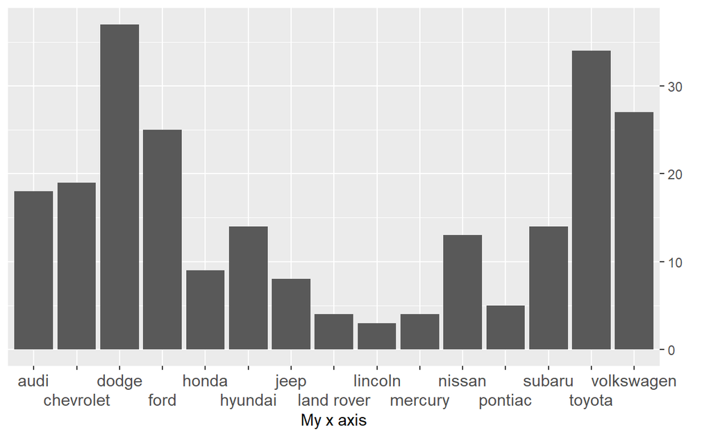

```r
p +
  guides(x = guide_axis(title = "My x axis", n.dodge = 2),
         y = guide_axis(title = "",
                        position = "right"))
```